# Fundamentals of Data Analysis Tasks 2020

# Task 1: counts

This task was accomplished by writing the counts(**input_list**) function (where **input_list** is an argument with data type list) in Python, shown below.

The function uses the unique(**list1**) function (where **list1** is an argument with data type list) to get a list of unique elements from list1 (i.e. if the element is present in list1, it will be present in the unique list only once, irrespective of how many times it is present in list1). This was taken from the website GeeksforGeeks 1.

The essence of the algorithm for counts is that the unique list of **input_list** is searched and each element is compared with each element of **input_list**. If there is a match, a dictionary is incremented with the key being equal to the element of the unique list. This particular algorithm was created for this Task and was not copied from an external source (although it is a specific solution to the general problem of counting frequencies in a list) 2

The algorithm for unique(**list1**) is given as follows:

1. An empty list called **return_list** is defined.
2. Each element of **list1** (called **x**) is traversed in a for loop.
3. In the loop, if **x** is not in **return_list**, **x** is appended to **return_list**.

When the traversal of **list1** is finished, **return_list** is returned by unique(**list1**).

The algorithm for counts(**input_list**) is given as follows:

1. unique(**list1**) is called with **input_list** as the argument **list1**.
2. The return value of this call is assigned to **unique_list**.
3. Each element of **unique_list** (called **i**) is traversed in a for loop.
4. A value of 0 is assigned to the dictionary **output_dict** in the loop at key = **i**.
5. Each element of **input_list** (called **j**) is traversed in another for loop in this loop.
6. If **i** equals **j**, the value of **output_dict** at key= **i** is incremented.

When the traversal of unique_list is finished, **output_dict** is returned by counts(**input_list**).

The function definition for unique() is given as follows:

```python
# function to get unique values
def unique(list1):

    # intilize empty list
    return_list = []

    # traverse for all elements
    for x in list1:
        # check if exists in unique_list or not
        if x not in return_list:
            return_list.append(x)
    # return unique_list
    return return_list
```

The function definition for counts() is given as follows:

```python
# Assigns how many times an entry appears
# in the list argument input_list to a
# dictionary. The dictionary's keys are
# the unique elements of input_list
def counts(input_list):

    # The dictionary counts returns
    output_dict = {}
    # Unique elements of input_list
    unique_list = unique(input_list)

    # Traverse each element of unique_list:
    for i in unique_list:
        # the number is initially 0 for each key of output_dict
        output_dict[i] = 0
        # Traverse each element of the original input_list
        for j in input_list:
            # if element of unique_list = element of input_list
            if(i==j):
                # increase the count for each key of output_dict
                output_dict[i] += 1

    # Return the dictionary
    return output_dict
```

A test input list is used as the argument input_list:

```python
input_list = ['A','A','B','C','A']
counts(input_list)
```

```
{'A': 3, 'B': 1, 'C': 1}
```

The result has been verified to be correct.

# Task 2: dicerolls

The function works by using numpy to generate random integers between 1 and 6 inclusive for **k** die, summing the result to get the total face value. This process is repeated **n** times.

The algorithm for the dice_rolls is given as follows:

1. An empty dictionary called **output_dict** is defined.
2. A variable called **sum** is defined and set to 0.
3. A for loop with range 0 and **n** is called.
4. In the for loop, a function from the **random** module in the **numpy** package called randint is called 3.
5. This function generates a list of randomly generated integers from 1 to 7 called **dice_rolls**. The list is of size **k**.
6. **dice_rolls** is summed using the sum function from the **numpy** package. The variable called **sum** is set to this sum.
7. An if statement determines if **sum** is not already in the keys of the dictionary **output_dict**
8. If the if statement returns True, than **output_dict** at key **sum** is set to 1.
9. If it returns False, an else statement increments the **output_dict** at key **sum** by 1.

The dicerolls function is called with **n**=1000 and **k**=2. The result is set to **d**.

```python
# numpy for numpy array
import numpy as np
# collections for OrdererdDict
import collections
# pyplot for plotting.
import matplotlib.pyplot as plt

# dicerolls function
def dicerolls(k, n):

    # output_dict empty dictionary
    output_dict = {}
    # sum variable set to 0
    total_face_value = 0

    # for loop from 0 to n
    for i in range(0, n):

        # dice_rolls numpy array of random integers from 1 (inclusive) to 7 (not inclusive)
        # to simulate dice roll. This is done k times (number of die=k)
        dice_rolls = np.random.randint(1, 7, size=k)

        # sum is set to sum of dice_rolls
        total_face_value = dice_rolls.sum()

        # if sum is not in the keys of output_dict
        # set output_dict[sum] to 1.
        # else increment output_dict by 1
        if(total_face_value not in output_dict.keys()):
            output_dict[total_face_value] = 1
        else:
            output_dict[total_face_value] += 1

    # output_dict is return value of dice rolls
    return output_dict

# d is set to dicerolls, with n = 1000 and k = 2
d = dicerolls(2, 1000)
print(d)
```

```
{7: 174, 8: 139, 9: 101, 6: 137, 5: 124, 4: 84, 10: 79, 2: 25, 12: 25, 3: 51, 11: 61}
```

In order to compare the result with the dictionary shown in the assignment PDF, the keys should be sorted. This is accomplished using the OrderedDict function from the **collections** 4 package.

```python
od = collections.OrderedDict(sorted(d.items()))

# create string of results to compare
str_out = ''
str_out += '{'
for k, v in od.items():
    str_out +="{}: {}, ".format(k, v)

# output string
str_out = str_out[:-2]
str_out += '}'

# print out the output string
print(str_out)
# the dictionary shown in the assignment PDF
test_dict = {2:19, 3:50, 4:82, 5:112, 6:135, 7:174, 8:133, 9:114, 10:75, 11:70, 12:36}
print(test_dict)
```

```
{2: 25, 3: 51, 4: 84, 5: 124, 6: 137, 7: 174, 8: 139, 9: 101, 10: 79, 11: 61, 12: 25}
{2: 19, 3: 50, 4: 82, 5: 112, 6: 135, 7: 174, 8: 133, 9: 114, 10: 75, 11: 70, 12: 36}
```

As can be seen, the dictionary **d** (with sorted keys) is very similar to the dictionary shown in the assignemnt (called **test_dict** here). This is further confirmed by comparing the two dictionaries side by side in a bar chart using the **pyplot** module from the **matplotlib** package 5:

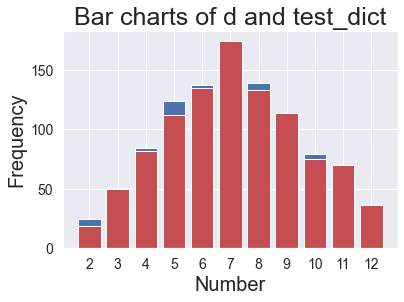

```python
# Bar chart plots
plt.bar(list(d.keys()), d.values(), color='b', label='Dice rolls')
plt.bar(list(test_dict.keys()), test_dict.values(), color='r', label='Test dict')

# Bar chart title
plt.title("Bar charts of d and test_dict", fontsize=25)

# the x label of bar charts
plt.xlabel("Number", fontsize=20)

# the y label of bar charts
plt.ylabel("Frequency", fontsize=20)

# change size of ticks of x and y axes
ax = plt.gca()
ax.tick_params(axis = 'both', which = 'major', labelsize = 14)

# Show all xticks
plt.xticks(list(d.keys()))

# Show plot after all is said and done
plt.show()
```

The blue chart represents the dictionary **d** and the red chart represents the dictionary **test_dict**. As can be seen from the charts, they overlap a great deal and are very similar.

# Task 3: coin flipping

The task is to show that flipping a coin repeatedly and plotting the distribution of the number of heads results in a bell-shaped curve. This is accomplished using the numpy.random.binomial function in the **random** module in the **numpy** package. 6

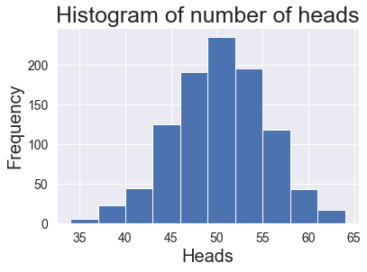

```python
# numpy for numpy array and binomial
import numpy as np
# pyplot for plotting.
import matplotlib.pyplot as plt

# this generates a list of size 1000
# each element of list is sum
# of number of successes in each
# coin toss simulation, where
# a coin is flipped 100 times
coin_flip = np.random.binomial(100, 0.5, 1000)

# plot histogram of sum_heads
plt.hist(coin_flip);

# Histogram
plt.title("Histogram of number of heads", fontsize=25)

# the x label of histogram
plt.xlabel("Heads", fontsize=20)

# the y label of histogram
plt.ylabel("Frequency", fontsize=20)

# change size of ticks of x and y axes of histogram
ax = plt.gca()
ax.tick_params(axis = 'both', which = 'major', labelsize = 14)
```

As can be seen from the histogram, the distribution of **coin_flip** resembles a Gaussian/normal distribution or bell curve. Most of the values are close to the mean of **coin_flip** (50) and the number of heads decreases the further away the value is from the mean. However, this can be made clearer by plotting the dataset using a kernel density estimate (KDE) plot. KDE plots first estimate the probability density function of a random variable using a given dataset and then plots the resulting PDF. This is accomplished using the **seaborn** module which has the function kdeplot.

First, a dataset called **normal_pdf** is generated using the probability density function of the normal distribution 8, the mean, standard deviation and size being equal to the mean, standard deviation and size of **coin_flip**. Then the KDE graphs of **coin_flip** are plotted on the same axes of a plot of **normal_pdf** using the plot function in **pyplot** to compare the normal distribution with the distribution of **coin_flip**:

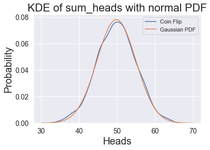

```python
# import seaborn for kdeplot
import seaborn as sns
# make grid to enhance
# and clarify graphs
sns.set()

# generate x values in range of histogram shown previously
x = np.linspace(30, 70, len(coin_flip))

# calculate multiplicative factors of PDF of normal distribution
f1 = 1/(np.std(coin_flip)*np.sqrt(2*np.pi))
f3 = x - np.mean(coin_flip)
f2 = (f3*f3)/(np.std(coin_flip)*np.std(coin_flip))
# calculate PDF using multiplicative factors
normal_pdf = f1*np.exp(-0.5 * (f2))


# Plot KDE of coin_flip and plot of normal_pdf
# on same axes
sns.kdeplot(coin_flip, label='Coin Flip');
plt.plot(x, normal_pdf, label='Gaussian PDF');

# Title of plots
plt.title("KDE of sum_heads with normal PDF", fontsize=22)

# the x label of plots
plt.xlabel("Heads", fontsize=20)

# the y label of plots
plt.ylabel("Probability", fontsize=20)

# change size of ticks of x and y axes of plots
ax = plt.gca()
ax.tick_params(axis = 'both', which = 'major', labelsize = 14)

# add legend to plot
plt.legend();
```

As can be seen from the graph, the distribution of **coin_flip** is very close to the normal distribution.

# Task 4: Simpson's paradox

The task is to demonstate Simpson's paradox. This is accomplished by using the **normal_multivarate** function from the **numpy.random** module. 9.

Simpson's paradox is the phenomenon whereby relationships, trends and correlations observed for particular sections of data change direction when the data is aggregated. An archetypal example is the phenomenon showing sex bias in graduate school admissions in UC Berkeley in California 10.

This phenomenon applies to continuous datasets as well. This is demonstrates using the **multivariate_normal** function in the **numpy.random** module. Imagine an engineering company trying to increase the longevity of a device they make by increasing the density of the material the device is made from, for example.

The company discovers through 1000 experiments that the mean longevity is 10 years, the mean density is 8050 kg/m<sup>3</sup>, the standard deviation of the longevity is 5 years and the standard deviation of the density is 50 kg/m<sup>3</sup>. They also discover a positive correlation of 0.35 between the density and longevity.

In aggregate, the data is generated like this (the dataset is initially generated by creating a covariance matrix from the correlation matrix to use in **multivariate_normal** 11)

```python
# calculate covariance matrix from correlation matrix
from statsmodels.stats.moment_helpers import corr2cov
# mean longevity is 10 years
# mean density is 8,050 kg/m^3
mean = [10, 8050]
# the standard deviation of the longevity
# is 5 years, the density is 50
std = [5, 50]

# the correlation between these two variables is 0.4
# and this correlation matrix reflects this
correlation = [[1, 0.35],[0.35, 1]]

# using corr2cov to generate covariance matrix
cov = corr2cov(correlation, std)

# y = longevity in years, x = density in kg/m3
# from multivariate_normal
y, x = np.random.multivariate_normal(mean, cov, 1000).T
```

A scatterplot with a linear regression of the data is as follows:

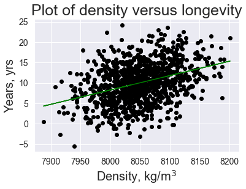

```python
import matplotlib.pyplot as plt
#Plotting the data

def dens_plot():
    # scatter plot of data set
    plt.scatter(x, y, color="black");

    # Title of plot
    plt.title("Plot of density versus longevity", fontsize=25)

    # the x label of plot
    plt.xlabel("Density, kg/m$^3$", fontsize=20)

    # the y label of plot
    plt.ylabel("Years, yrs", fontsize=20)

    # change size of ticks of x and y axes
    ax = plt.gca()
    ax.tick_params(axis = 'both',which = 'major', labelsize = 14)

# linear regression of dataset
from sklearn.linear_model import LinearRegression

# reshape arrays for LinearRegression
X = x.reshape(-1,1)
Y = y.reshape(-1,1)
reg = LinearRegression().fit(X,Y)

# Make predictions using the testing set
y_pred = reg.predict(X)
# plot the line
plt.plot(x, y_pred, color="green")

dens_plot()
plt.show()
```

The positive correlation can be plainly seen from the plot. The correlation is further confirmed as follows by taking the square root of the coefficent of determination:

```python
# to get r^2, coefficient of determination
from sklearn.metrics import r2_score
# get square root to get correlation coefficient
r = np.sqrt(r2_score(y, y_pred))
print("Correlation: {}".format(r))
```

```
Correlation: 0.3668682323838152
```

However, it turns out that the steel was treated using different methods (called methods A,B,C and D). Method A was used for densities less than 7975 kg/m<sup>3</sup>. Method B was used for densities less than 8035 kg/m<sup>3</sup> and greater than 7975 kg/m<sup>3</sup>. Method C was used for densities less than 8125 kg/m<sup>3</sup> and greater than 8035 kg/m<sup>3</sup>. Method D was used for densities greater than 8125 kg/m<sup>3</sup>.

```python
# dividing up x values
xa = x[x<7975]
xb = x[x>7975]
xb = xb[xb<8035]
xc = x[x>8035]
xc = xc[xc<8125]
xd = x[x>8125]

# reshaping the values for linear regression
Xa = xa.reshape(-1,1)
Xb = xb.reshape(-1,1)
Xc = xc.reshape(-1,1)
Xd = xd.reshape(-1,1)

# dividing up y values
ya = y[0:len(Xa)]
yb = y[len(Xa):len(Xb)+len(Xa)]
yc = y[len(Xb)+len(Xa):len(Xc)+len(Xb)+len(Xa)]
yd = y[len(Xc)+len(Xb)+len(Xa):1000]

# reshaping y values for linear regression
Ya = ya.reshape(-1,1)
Yb = yb.reshape(-1,1)
Yc = yc.reshape(-1,1)
Yd = yd.reshape(-1,1)
```

The regressions using this data is done as follows:

```python
# regression for each partition
rega = LinearRegression().fit(Xa,Ya)
regb = LinearRegression().fit(Xb,Yb)
regc = LinearRegression().fit(Xc,Yc)
regd = LinearRegression().fit(Xd,Yd)

# predicted values for each partition
ya_pred = rega.predict(Xa)
yb_pred = regb.predict(Xb)
yc_pred = regc.predict(Xc)
yd_pred = regd.predict(Xd)
```

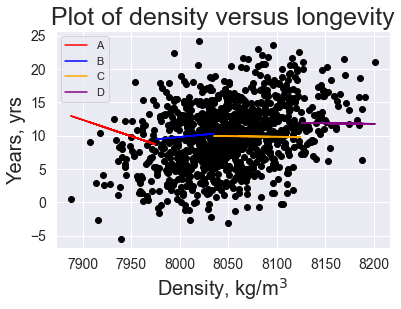

```python
# plot the regression lines with dataset
dens_plot()
plt.plot(xa, ya_pred, color="red", label="A")
plt.plot(xb, yb_pred, color="blue", label="B")
plt.plot(xc, yc_pred, color="orange", label="C")
plt.plot(xd, yd_pred, color="purple", label="D")
plt.legend()
plt.show()
```

As can be seen from the graph Method A produces a negative correlation between density and longevity, Method B produces a small positive correlation. Method C produces a small negative correlation and Method D produces a small negative correlation. The correlation coefficients for these methods can be calculated:

```python
ra = np.sqrt(r2_score(ya, ya_pred))
print("Method A correlation: -{}".format(ra))

rb = np.sqrt(r2_score(yb, yb_pred))
print("Method B correlation: {}".format(rb))

rc = np.sqrt(r2_score(yc, yc_pred))
print("Method C correlation: -{}".format(rc))

rd = np.sqrt(r2_score(yd, yd_pred))
print("Method D correlation: -{}".format(rd))

# Overall correlation for comparison
r = np.sqrt(r2_score(y, y_pred))
print("")
print("Overall correlation: {}".format(r))
```

```
Method A correlation: -0.20646999578084513
Method B correlation: 0.04702655836417431
Method C correlation: -0.005865568978052437
Method D correlation: -0.006282814305167008

Overall correlation: 0.3668682323838152
```

Method A produces a small negative correlation, Method B produces a statistically insignificant positive correlation. Method C produces a statistically insigificant negative correlation and Method D produces a statistically insignificant negative correlation. This is is in constrast to the correlation for the data in aggregate.

This is a hypothetical dataset but if this was real an explanation could be that the different methods used themselves effect the longevity independent of the density. So Method A does not effect the longevity significantly but Method B causes a large jump in longevity, as does Method C and D.

These jumps would not be apparent overall because it looks like increasing the density is what is causing the increase in longevity because of the positive correlation. This would be an example of "correlation does not imply causation" 12.

This demonstrates Simpson's paradox that aggregating the data and produce different correlations, relationships and trends as opposed to dividing the data into its constituent groupings.

## References

[1] Geeks for Geeks, accessed 7 October 2020, https://www.geeksforgeeks.org/python-get-unique-values-list/  
[2] GeeksforGeeks. 2020. Counting The Frequencies In A List Using Dictionary In Python - Geeksforgeeks. [online] Available at: https://www.geeksforgeeks.org/counting-the-frequencies-in-a-list-using-dictionary-in-python/ [Accessed 17 December 2020].  
[3] Numpy.org. 2020. Random Sampling (Numpy.Random) — Numpy V1.19 Manual. [online] Available at: https://numpy.org/doc/stable/reference/random/index.html# [Accessed 7 November 2020].  
[4] Docs.python.org. 2020. 8.3. Collections — High-Performance Container Datatypes — Python 2.7.18 Documentation. [online] Available at: https://docs.python.org/2/library/collections.html [Accessed 7 November 2020].  
[5] Matplotlib.org. 2020. Pyplot — Matplotlib 2.0.2 Documentation. [online] Available at: https://matplotlib.org/api/pyplot_api.html [Accessed 7 November 2020].  
[6] Numpy.org. 2020. Numpy.Random.Binomial — Numpy V1.19 Manual. [online] Available at: https://numpy.org/doc/stable/reference/random/generated/numpy.random.binomial.html [Accessed 16 November 2020].  
[7] Eecs.harvard.edu. 2020. [online] Available at: http://www.eecs.harvard.edu/~michaelm/coinflipext.pdf [Accessed 16 November 2020].  
[8] Probabilitycourse.com. 2020. Normal Distribution | Gaussian | Normal Random Variables | PDF. [online] Available at: https://www.probabilitycourse.com/chapter4/4_2_3_normal.php [Accessed 16 November 2020].  
[9] Numpy.org. 2020. Numpy.Random.Multivariate_Normal — Numpy V1.19 Manual. [online] Available at: https://numpy.org/doc/stable/reference/random/generated/numpy.random.multivariate_normal.html [Accessed 2 December 2020].  
[10] Bickel, P., Hammel, E. and O'connell, J., 2020. Sex Bias In Graduate Admissions: Data From Berkeley. [online] Semanticscholar.org. Available at: https://www.semanticscholar.org/paper/Sex-Bias-in-Graduate-Admissions%3A-Data-from-Berkeley-Bickel-Hammel/f8017421f0c120a1f0b39c531aa7d2c75c842361 [Accessed 2 December 2020].  
[11] Medium, 2020, Let Us Understand The Correlation Matrix And Covariance Matrix. [online] Available at: https://towardsdatascience.com/let-us-understand-the-correlation-matrix-and-covariance-matrix-d42e6b643c22. [Accessed 16 December 2020]  
[12] Medium 2020, Why Correlation Does Not Imply Causation? [online] Available at: https://towardsdatascience.com/why-correlation-does-not-imply-causation-5b99790df07e.